# Part I - Prosper Loan Dataset Exploration

## Multivariate Exploration

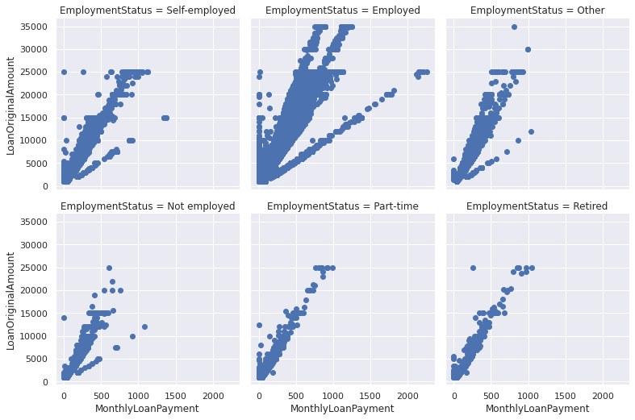

```python
g1 = sb.FacetGrid(data = loan_clean, col = 'EmploymentStatus',col_wrap=3,size=3.7)
g1.map(plt.scatter,'MonthlyLoanPayment','LoanOriginalAmount')
```

There is postive relation between the loan amount and monthly payment across every employment

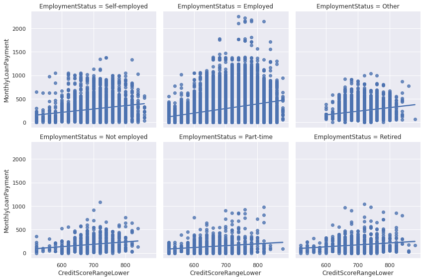

```python
g2 = sb.FacetGrid(data = loan_clean, col = 'EmploymentStatus',col_wrap=3,size=4)
g2.map(sb.regplot,'CreditScoreRangeLower','MonthlyLoanPayment')
```

The linear trend is screen across all employment status but the slope of the linear trend varies. and the employed status has the steepest slope

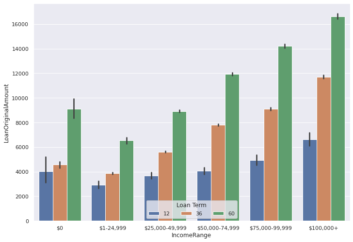

```python
sb.set(rc={'figure.figsize':(11.7,8.27)})
ax = sb.barplot(data = prp_sc, x = 'IncomeRange', y = 'LoanOriginalAmount', hue = 'Term')
ax.legend(loc = 8, ncol = 3, framealpha = 0.8, title = 'Loan Term')
```

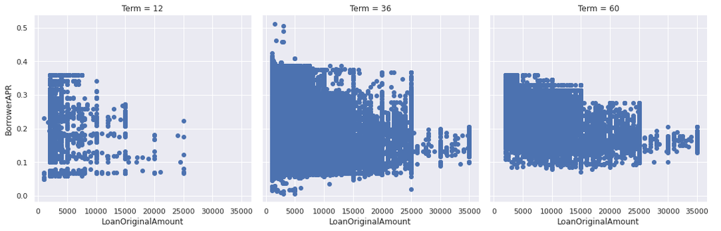

```python
g3 = sb.FacetGrid(data = loan_clean, col = 'Term', size = 5)
g3.map(plt.scatter, 'LoanOriginalAmount', 'BorrowerAPR')
g3.add_legend();
```

More point fall in the 36 month term and the 60 month term shows a stronger negative correlation between the BorrowerAPR and the Loan amount

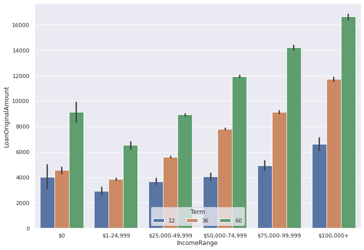

```python
sb.set(rc={'figure.figsize':(11.7,8.27)})
ax = sb.barplot(data =prp_sc, x = 'IncomeRange', y = 'LoanOriginalAmount', hue = 'Term')
ax.legend(loc = 8, ncol = 3, framealpha = 0.8, title = 'Term')
```

This chart captures something of interest that loan amount of 60 month term tend to be larger than the loans of other amount . It seems there is a relationship betwwen the loan terms and amount and somewhat a positve relationship between the loan term , loan amount and the income range with the exception of a drop in value in the income range of 1-24,999

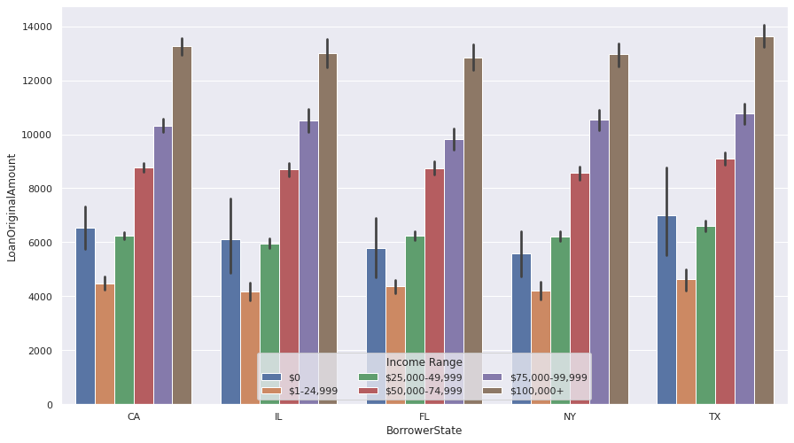

```python
sb.set(rc={'figure.figsize':(14.7,8.27)})
ax = sb.barplot(data = loan_clean_state2, x = 'BorrowerState', y = 'LoanOriginalAmount', hue = 'IncomeRange')
ax.legend(loc = 8, ncol = 3, framealpha = 0.8, title = 'Income Range')
```

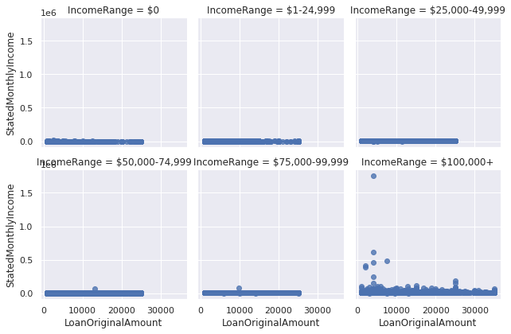

```python
g3 = sb.FacetGrid(data = loan_clean, col = 'IncomeRange',col_wrap=3)
g3.map(sb.regplot,'LoanOriginalAmount','StatedMonthlyIncome');
```

no information can be gotten from the regplot although a linear trend with no visible slope can be see across each plot

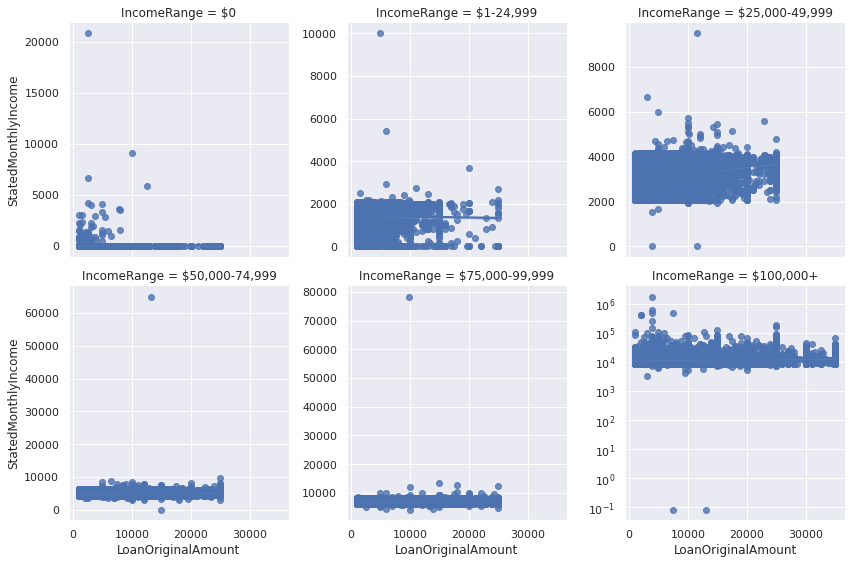

```python
g4 = sb.FacetGrid(data = loan_clean, col = 'IncomeRange',col_wrap=3,sharey=False,size=4)
g4.map(sb.regplot,'LoanOriginalAmount','StatedMonthlyIncome')
plt.yscale('log');
```

- There is no obvious correlation but a linear trend can be seen in the stated income and loan amount
- The income Range of 0 dollars has an outlier at 20,000 dollars and some peole have stated monthly income above 5k dollars

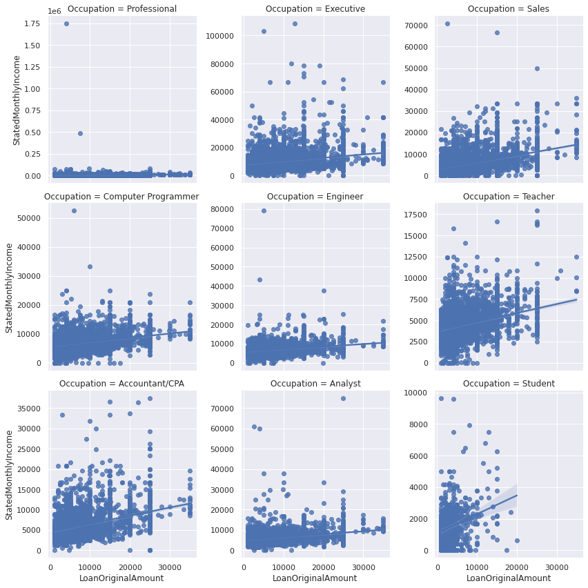

```python
g4 = sb.FacetGrid(data = loan_clean_occupation, col = 'Occupation',col_wrap=3,sharey=False,size=4)
g4.map(sb.regplot,'LoanOriginalAmount','StatedMonthlyIncome')
```

Some students have a monthly income of close to 10,000 dollars the scatter plot of the executives correct my thinking and shows some excutives have a monthly income of zero. i want to look into this futher by comparing the income ranges with the loan amount and occupation

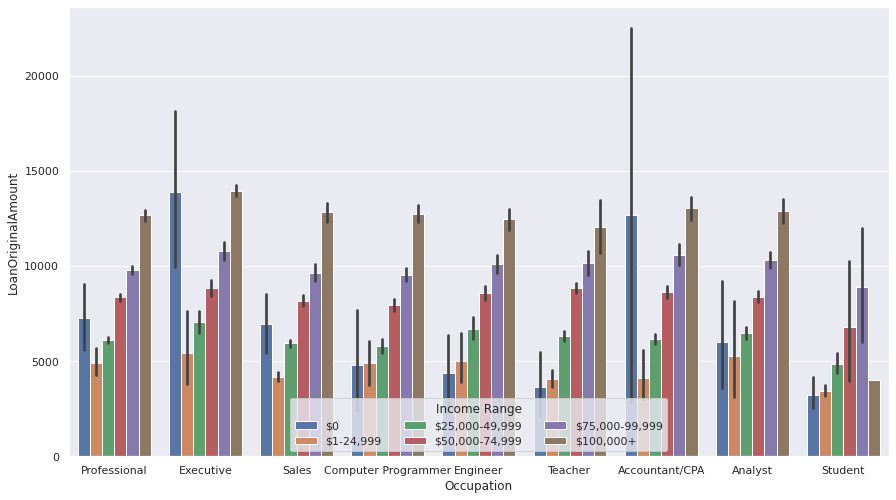

```python
sb.set(rc={'figure.figsize':(14.7,8.27)})
ax = sb.barplot(data = loan_clean_occupation, x = 'Occupation', y = 'LoanOriginalAmount', hue = 'IncomeRange')
ax.legend(loc = 8, ncol = 3, framealpha = 0.8, title = 'Income Range')
```

> There is a linear trend between income range and loan amount across occupations with deviations in the $0 income range

[figure not shown]

```python
sb.set(rc={'figure.figsize':(14.7,8.27)})
ax = sb.barplot(data = loan_clean_occupation, x = 'Occupation', y = 'LoanOriginalAmount', hue = 'CreditScore_levels')
ax.legend(loc = 8, ncol = 3, framealpha = 0.8, title = 'Income Range');
```

There seems to be somewhat a positive relationship between the credit score level and the loan amount, meaning a better credit score might improve your Loan Amount you can get, except in the case of students

### Were there any interesting or surprising interactions between features?

- States with higher monthly income average like CA didnt have significantly higher values than other states
- People in 0 dollars income range had stated monthly income of above 5,000 dollars and
- Some studnets have the income range of over 100k dollars and some excutives have an income range of \$0

## Conclusions

> My investigation on the Loan amount was insightful one of my significant discoveries was that your credit score range significantly affects the Loan amount you would be able to borrow. Your monthly income and your employment status. A larger loan Amount would come with longer loan terms and higher monthly loan payment

### References

- Udacity example project
- https://matplotlib.org/stable/api/_as_gen/matplotlib.pyplot.bar.html
- https://seaborn.pydata.org/